# 01.4 Entry Lab

This is the basic building blocks for the Python Tkinter window.

- Contents:
  1. Google Slides Link
  2. Repl.it Link
  3. Lab Overview - What is required.

     a. GUI Solution - This is what the final outcome should look like.

     b. READ.ME File - This is the objectives and rubric.

     c. Build.ME file- This is the code needed to complete the lab.

This lab and Google Slides covers the following content:

- Entry Widget
- Label Widget
- Button Widget
- Functions

# 1. Google Slides

[Miles Per Gallon Slides](https://docs.google.com/presentation/d/1qS-wCtpJCfghtDsXWNSfJb3Wbq-A71nULft254PZR4g/edit?usp=sharing)

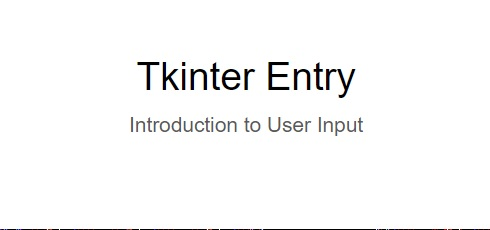

# 01.4 Entry Repl.it

[Entry / Miles Per Gallon Repl.it](https://replit.com/join/bcxlfcwe-erniedrumm)

[figure not shown]

# 3. Lab 01.4 Overview

- Use Build.ME file to construct main.py file.
- Ensure the main.py file runs with the basic python Tkinter libraries.
- Run examples 1-3
- Example 4 is associated with the Miles Per Gallon requirements.

## a. GUI Example for 01.4 Entry Lab

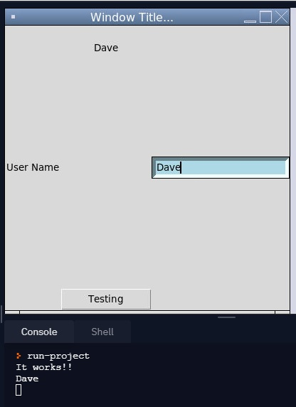

## b. The 'READ.ME' File

### This is a required read through because this file includes the directions, steps, objectives, point values, and rubric.

```python
#########################################################
##################    01.4 Entry        #################
##################  Miles Per Gallon    #################
#########################################################
#                                                       #
# Directions:                                           #
#       - Fork and save as 01.4_yourLastName            #
#       - Read the Read.Me file!                        #
#       - Complete ALL steps to Build app               #
#       - Use the 'Build.ME' file for all your code.    #
#       - Submit your repl link on Schoology!!          #
#                                                       #
#  --------------------------------------------------   #
# Essential Setup Steps:                                #
#     Setup: Enter comments for Name, Date, Lab desc.   #
#     1. import * (ALL) the tkinter libraries           #
#     2. The Tk() class instance                        #
#     3. The .geometry method                           #
#     4. The .title method                              #
#     5. The .mainloop method                           #
#                                                       #
#  --------------------------------------------------   #
# Objectives:                                           #
#      1. Ensure the main.py file runs with the basic   #
#           python Tkinter libraries and window.        #
#      2. Run each example 1-3                          #
#      3. Example 4 is associated with the Miles        #
#          Per Gallon Lab requirements.                 #
#                                                       #
#  --------------------------------------------------   #
# New Python Content:                                   #
#           Entry                                       #
#           Entry Parameters                            #
#           Combining Tkinter Widgets                   #
#           Getting user input .get()                   #
#           Displaying User input in a label            #
#                                                       #
#  --------------------------------------------------   #
# Point Values:                                         #
#        Comments:                                      #
#                   name, date, description   5         #
#                                                       #
#        Miles Per Gallon Runs as intended:   5         #
#                                                       #
#        Labels (Miles Driven, Gallons Used:  5         #
#                                                       #
#        Entry (Miles Driven, Gallons Used:   5         #
#                                                       #
#        MPG calculated and displayed:        5         #
#                                                       #
#                                            25 Total   #
#                                                       #
#  --------------------------------------------------   #
#  Rubric:                                              #
#                                                       #
#      Update Comments                                  #
#               0-1           2-3          4-5          #
#          ------------   ------------   ------------   #
#               No         Some           Lots of       #
#            Comments       Comments       comments     #
#               No         Little         Lots of       #
#             Updates        Detail        details      #
#                                         Updated       #
#                                                       #
#                                                       #
#      Miles Per Gallon Runs as Intended                #
#              0-1           2-4             5          #
#         ------------   ------------   ------------    #
#         Does not run   Runs with      Runs with no    #
#          or no code     errors or      errors.        #
#          and/or wrong   unexpected    Runs as intended#
#          code.          results.      Additional      #
#                                        features do not#
#                                        effect app     #
#                                                       #
#                                                       #
#      Labels (Miles Driven, Gallons Used)              #
#              0-1           2-4             5          #
#         ------------   ------------   ------------    #
#         No labels or   Spelling       Label is        *
#          does not say   issues or      present and    #
#          anything       not in         can see in the #
#          about subject  label         GUI window.     #
#                                                       #
#      Entry (Miles Driven, Gallons Used)               #
#              0-1           2-4             5          #
#         ------------   ------------   ------------    #
#         No Entry or    Mostly works   Entry is        #
#          does not       but issues     present and    #
#          work           or not both    can enter data.#
#                         entrys present                #
#                                                       #
#      Miles Per Gallon Calculated and Displayed        #
#              0-1           2-4             5          #
#         ------------   ------------   ------------    #
#         No results     Missing one    Works and       #
#          or not         part or not    provides       #
#          working at     working        correct data   #
#          all.           correctly.    No errors.      #
#                         OR incorrect                  #
#                         calculations.                 #
#                                                       #
#                                                       #
#########################################################
```

## c. The 'Build.ME' File

### This file includes all the code necessary to get the lab up and running. It is divided into important sections.

```python
# Objectives.
#   1. Ensure basic window works.
#   2. Add code and run each example 1-4.
#       a. Entry basic
#       b. Entry Enhanced
#       c. Buttons, functions
#       b. Miles Per Gallon Lab

""" Example 1. Entry Basic

my_entry = Entry(root, width = 20)
my_entry.insert(0,'Username')
my_entry.pack(padx = 5, pady = 5)

my_entry2 = Entry(root, width = 15)
my_entry2.insert(0,'password')
my_entry2.pack(padx = 5, pady = 5)


"""


""" Example 2. Entry Enhanced

## root.geometry("150x50")
labelName = Label(root, text="User Name")
labelName.pack(side=LEFT)
entryName = Entry(root, bd =5)
entryName.pack(side = RIGHT)

# entryName = Entry(root, fg="yellow",bg="lightblue",width=50, bd =5)


"""


"""  Example 3. Buttons, functions

def button_command():
  print("It works!!")
  print(entryName.get())
  labelNameDisplay = Label(root, text=entryName.get())
  labelNameDisplay.pack()
  return None

labelName = Label(root, text="User Name")
labelName.pack(side=LEFT)

entryName = Entry(root, fg="black",bg="lightblue", width=20, bd =5, cursor="crosshair")
entryName.pack(side = RIGHT)

Button_1 = Button(root, text="Testing", width=20, command=button_command).pack(side=BOTTOM)

usrName = entryName.get()

labelNameDisplay = Label(root, text=usrName)
labelNameDisplay.pack()

"""




"""  Example 4. Miles Per Gallon

1. Label for Miles Driven:
2. Label for Gallons Used:
3. Entry for Miles Driven
4. Entry for Gallons used
5. Button to perform calculations
6. Label for output.
7. Function for Button Event
8. Perform Calculations in Button Function.


"""
```

## Resources

#### Sources and deeper learning research:

1. Python Tkinter Canvas Widget. Studytonight Technologies Pvt. Let. 2021. 3/30/2021. https://www.studytonight.com/tkinter/python-tkinter-canvas-widget
1. W3Schools.com - [Python GUI Programming](https://www.w3schools.in/python-tutorial/gui-programming/)
1. RepL.it. https://replit.com/~